# EE0848 Machine Learning for SP

Week 10: Convolutional Neural Networks

Basri Erdogan

# Convolutional Neural Networks

## Agenda

- CNN intuition & motivation
- Discrete convolution math (recap for SP students)
- Core building blocks: Conv → BN → ReLU → Pool
- Regularization: BatchNorm, Dropout, Data Augmentation
- PyTorch end-to-end: model → train → evaluate
- Landmark architectures & transfer learning
- CNNs for 1-D signals (SP connection)

## What is a CNN?

- Learns **filters** (kernels) that slide across the input to detect patterns.
- Exploits **local connectivity** + **weight sharing** → huge parameter savings.
- State-of-the-art on images, **audio spectrograms**, and **1-D sensor signals**.
- Core inductive biases: **locality**, **weight sharing**, **translation equivariance**.

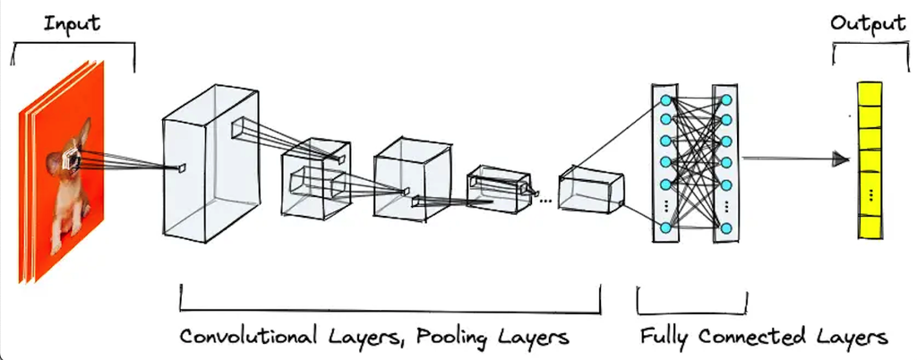

High-level CNN pipeline

## Why Convolutions?

|  | **Dense Layer** | **Convolution** |
| --- | --- | --- |
| **Connectivity** | Every neuron ↔︎ every pixel → parameter **explosion** | Filter $K \times K \times C$ reused across spatial positions |
| **Inductive bias** | No assumption about locality | Explicit bias: nearby samples matter most |
| **Translation** | **Variant** — moving an object changes output | **Equivariant** — shift input → shift output |
| **Params (example)** | 32×32×3 input → 256 neurons = **786k** weights | 3×3×3 filter × 256 = **7k** weights |

# Convolution Operation

## Discrete Convolution (1-D) Recap

**Convolution** (DSP definition):
$$y[n] = (x * h)[n] = \sum_{m} x[m]\, h[n-m]$$

**Cross-correlation** (what DL frameworks actually compute):
$$(x \star h)[n] = \sum_{m} x[m]\, h[n+m]$$

**Note**

The kernel is **learned**, so the flip doesn’t matter — it’s absorbed into the learned weights. The operation matches your DSP course; what differs is the kernel is **trained from data**, not hand-designed.

## 2-D Convolution: Step-by-Step

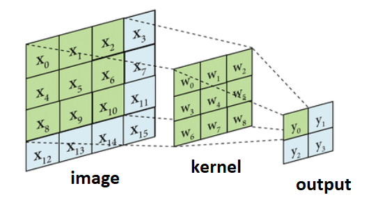

Kernel sliding over image grid

**Numerical example** (3×3 kernel, no padding, stride 1):

$$\text{Input patch} = \begin{bmatrix} 1 & 0 & 1 \\ 0 & 1 & 0 \\ 1 & 0 & 1 \end{bmatrix} \quad \text{Kernel} = \begin{bmatrix} 1 & 0 & -1 \\ 1 & 0 & -1 \\ 1 & 0 & -1 \end{bmatrix}$$

$$\text{Output} = \sum_{i,j} \text{input}_{ij} \cdot \text{kernel}_{ij}$$
$$= 1{\cdot}1 + 0{\cdot}0 + 1{\cdot}({-1}) + 0{\cdot}1 + 1{\cdot}0 + 0{\cdot}({-1}) + 1{\cdot}1 + 0{\cdot}0 + 1{\cdot}({-1}) = \mathbf{0}$$

Slide the kernel to the next position → next output value.

## Output Size Formula

For a given spatial dimension:

$$\boxed{H_{\text{out}} = \left\lfloor \frac{H_{\text{in}} - K + 2P}{S} \right\rfloor + 1}$$

| Symbol | Meaning | Typical values |
| --- | --- | --- |
| $K$ | Kernel size | 3, 5, 7 |
| $P$ | Padding | 0 (valid), $\lfloor K/2 \rfloor$ (same) |
| $S$ | Stride | 1 (preserve size), 2 (downsample) |

**Quick examples** (input 32×32):

- $K=3, P=1, S=1$ → $\lfloor(32-3+2)/1\rfloor+1 = 32$ (same)
- $K=3, P=0, S=1$ → $\lfloor(32-3+0)/1\rfloor+1 = 30$ (shrinks by 2)
- $K=3, P=1, S=2$ → $\lfloor(32-3+2)/2\rfloor+1 = 16$ (halved)

## Stride & Padding Visual

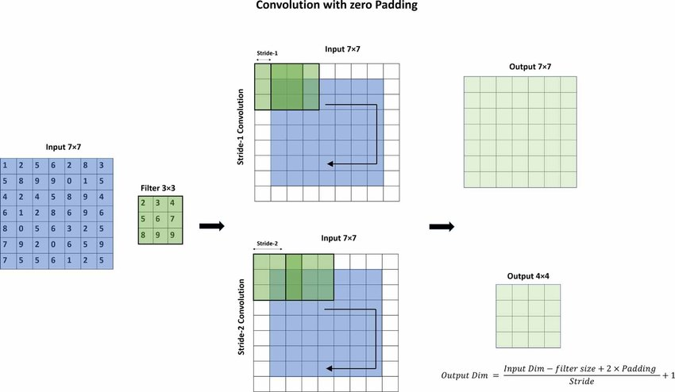

Stride 2 vs Stride 1, plus zero-padding

**Stride:**

- Stride 1 → kernel moves 1 pixel at a time
- Stride 2 → kernel jumps 2 pixels → **halves** spatial resolution
- Larger stride = more aggressive downsampling

**Padding:**

- No padding → output shrinks, borders ignored
- Zero-padding → **preserves** spatial dimensions
- “Same” padding: $P = \lfloor K/2 \rfloor$

## Receptive Field

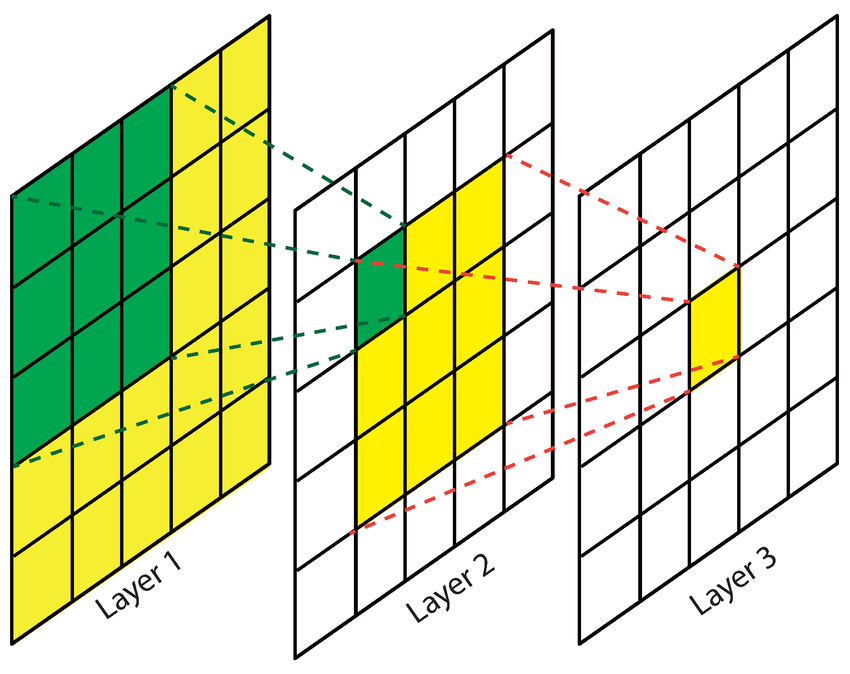

Receptive field stacking

The **receptive field** is the region of the input that influences a single output neuron.

- Layer 1 (3×3 kernel): sees a **3×3** patch
- Layer 2 (3×3 kernel): sees a **5×5** patch of the original input
- Layer 3: sees **7×7**, and so on…

$$R_l = R_{l-1} + (K_l - 1) \prod_{i=1}^{l-1} S_i$$

**Why it matters:** deeper layers “see” larger portions of the input → can detect **higher-level** patterns.

# Building Blocks

## CNN Building Blocks Overview

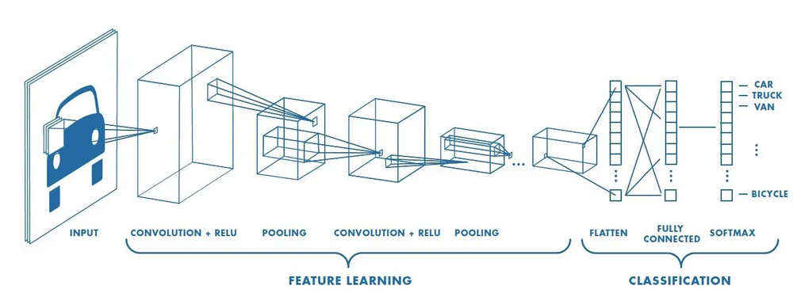

CNN Building Blocks

| Block | Purpose |
| --- | --- |
| **Conv → ReLU** | Non-linear feature extraction |
| **Batch Normalization** | Stabilize training, enable higher learning rate |
| **Pooling** (max / avg) | Downsample, add translation invariance |
| **Dropout** | Regularize fully-connected layers |
| **FC head** | Map high-level features → class logits |

## What Each Layer Learns

As we go deeper, the features become increasingly abstract:

| Depth | Learns | Example |
| --- | --- | --- |
| **Layer 1** | Edges, gradients, colors | Horizontal/vertical lines |
| **Layer 2–3** | Textures, corners, patterns | Grid patterns, curves |
| **Layer 4–5** | Object parts | Eyes, wheels, windows |
| **Deep layers** | Whole objects, scenes | Faces, cars, buildings |

**Note**

This hierarchy emerges automatically from training — we never tell the network to learn edges first. The architecture (local kernels + pooling) naturally encourages this progression from low-level to high-level.

## Batch Normalization

Center & scale mini-batch activations:

$$\hat{x}_i = \frac{x_i - \mu_B}{\sqrt{\sigma_B^2 + \varepsilon}}, \qquad y_i = \gamma \hat{x}_i + \beta$$

**Training:**

- Compute $\mu_B$, $\sigma_B^2$ from the current mini-batch
- Learn per-channel **scale** ($\gamma$) and **shift** ($\beta$)
- Maintain running average of $\mu$ and $\sigma^2$

**Inference:**

- Use the **running average** statistics (not batch stats)
- This is why `model.eval()` matters!

**Benefits:**

- Reduces **internal covariate shift**
- Allows **higher learning rates**
- Slight regularization effect

## Pooling

**Max Pooling:**

- Keeps the **strongest activation** in each window
- Emphasizes the most salient feature
- Most common: 2×2 window, stride 2 → halves spatial dims

**Average Pooling:**

- Smooths — keeps the **mean activation**
- **Global Average Pooling (GAP):** average over entire spatial map → single value per channel
- Often replaces FC layers at the end → fewer parameters

**Both** add local **translation invariance**.

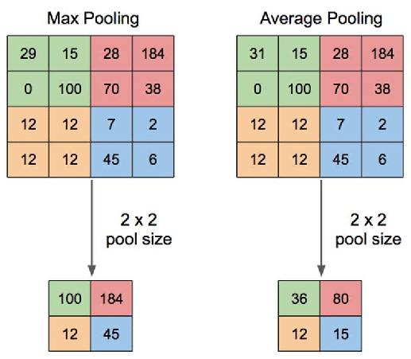

Pooling illustration

## Dropout

- During training, randomly **zero out** a fraction $p$ of activations.
- Prevents co-adaptation → forces redundant, robust features.
- Acts like training an **ensemble** of $2^n$ sub-networks.
- At **test time:** full network is used; outputs are scaled by $(1-p)$.

**Where to use it:**

- After FC layers: $p = 0.3{-}0.5$
- After late conv layers (optional): $p = 0.1{-}0.2$
- **Not** after BatchNorm — they interact poorly

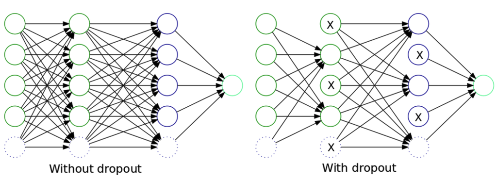

Dropout

## Fully Connected Head

- After the conv+pool blocks, **flatten** the feature maps.
- **Dense layer(s)** map high-level features → **logits** (one per class).
- Last layer output → **softmax** (handled by `CrossEntropyLoss` in PyTorch).

**Modern trend:** replace FC layers with **Global Average Pooling** → directly to logits. Fewer parameters, less overfitting.

```python
# Traditional: flatten → FC
x = x.flatten(1)          # [B, C*H*W]
x = self.fc(x)            # [B, num_classes]

# Modern: GAP → FC
x = x.mean(dim=[2, 3])    # [B, C]
x = self.fc(x)            # [B, num_classes]
```

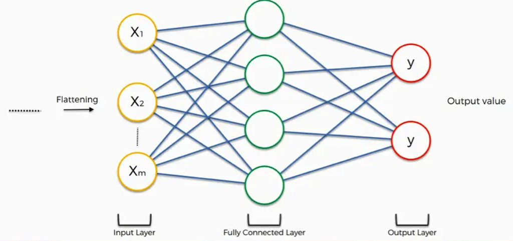

Fully Connected Layer

## Data Augmentation

```python
import torchvision.transforms as T

train_tf = T.Compose([
    T.RandomCrop(32, padding=4),
    T.RandomHorizontalFlip(),
    T.ColorJitter(0.1, 0.1, 0.1),
    T.RandomErasing(p=0.25),
    T.ToTensor(),
    T.Normalize((0.5,)*3, (0.5,)*3)
])
```

- Increases data diversity **without** new labels
- The single most effective regularizer for vision
- **Only applied during training** — test data stays clean

[figure not shown]

Before / after augmentation

# Training in PyTorch

## Model Definition (1/2)

```python
import torch.nn as nn
import torch.nn.functional as F

class a_CNN(nn.Module):
    def __init__(self):
        super().__init__()
        # Conv block 1: 3×32×32 → 16×32×32 → pool → 16×16×16
        self.conv1 = nn.Conv2d(3, 16, kernel_size=5, padding=2)
        self.bn1   = nn.BatchNorm2d(16)
        # Conv block 2: 16×16×16 → 32×16×16 → pool → 32×8×8
        self.conv2 = nn.Conv2d(16, 32, kernel_size=5, padding=2)
        self.bn2   = nn.BatchNorm2d(32)
        # Classifier head
        self.fc1   = nn.Linear(32 * 8 * 8, 64)
        self.drop  = nn.Dropout(0.3)
        self.fc2   = nn.Linear(64, 10)
```

**Parameter count:** ~145k — compare to a 2-layer FC on same input: ~800k+

## Model Definition (2/2) — Forward Pass

```python
    def forward(self, x):                      # x: [B, 3, 32, 32]
        x = F.relu(self.bn1(self.conv1(x)))    # → [B, 16, 32, 32]
        x = F.max_pool2d(x, 2)                 # → [B, 16, 16, 16]
        x = F.relu(self.bn2(self.conv2(x)))    # → [B, 32, 16, 16]
        x = F.max_pool2d(x, 2)                 # → [B, 32,  8,  8]
        x = x.flatten(1)                       # → [B, 2048]
        x = self.drop(F.relu(self.fc1(x)))     # → [B, 64]
        return self.fc2(x)                     # → [B, 10] (logits)
```

The pattern: **Conv → BN → ReLU → Pool** repeated, then **Flatten → FC → Dropout → FC**.

Returns **logits** — softmax is applied inside `CrossEntropyLoss`.

## Optimizer & Loss

```python
model = a_CNN().to(device)
opt   = torch.optim.AdamW(model.parameters(), lr=1e-3, weight_decay=1e-4)
loss_fn = nn.CrossEntropyLoss(label_smoothing=0.05)
```

| Component | Choice | Why |
| --- | --- | --- |
| **Optimizer** | AdamW | Adam with *decoupled* weight decay → better generalization |
| **Learning rate** | $10^{-3}$ | Good default for Adam-family optimizers |
| **Weight decay** | $10^{-4}$ | L2 regularization on weights |
| **Loss** | CrossEntropyLoss | Combines LogSoftmax + NLLLoss |
| **Label smoothing** | $\alpha = 0.05$ | Softens one-hot targets → prevents overconfidence |

## Learning Rate Scheduling

```python
sched = torch.optim.lr_scheduler.CosineAnnealingLR(opt, T_max=20)
```

**Cosine annealing:**
$$\eta_t = \eta_{\min} + \tfrac{1}{2}(\eta_{\max}-\eta_{\min})\left[1+\cos\left(\tfrac{\pi t}{T_{\max}}\right)\right]$$

| Scheduler | PyTorch Class | Behavior |
| --- | --- | --- |
| **Step** | `StepLR` | $\eta \gets \gamma\eta$ at milestones |
| **Cosine** | `CosineAnnealingLR` | Smooth cosine decay |
| **Cyclic** | `CyclicLR` | Triangular / cosine oscillations |

- Starts large (explore) → ends small (fine-tune).
- Smooth decay — no hand-tuned step milestones.

## Training Loop

```python
for epoch in range(20):
    model.train()                          # enable BN + Dropout
    running_loss = 0
    for xb, yb in train_dl:
        xb, yb = xb.to(device), yb.to(device)
        opt.zero_grad()                    # clear old gradients
        loss = loss_fn(model(xb), yb)      # forward + compute loss
        loss.backward()                    # compute gradients
        opt.step()                         # update weights
        running_loss += loss.item()
    sched.step()                           # update learning rate
    print(f"Epoch {epoch}: loss = {running_loss/len(train_dl):.3f}")
```

Key points:

- `model.train()` → enables BN running-stat updates and Dropout
- `opt.zero_grad()` → PyTorch **accumulates** gradients by default — must clear them
- `sched.step()` runs **once per epoch** (not per batch)

## Evaluation

```python
model.eval()                               # freeze BN stats, disable Dropout
correct, total = 0, 0
with torch.no_grad():                      # no gradient computation → faster
    for xb, yb in test_dl:
        out = model(xb.to(device))
        preds = out.argmax(dim=1)
        correct += (preds == yb.to(device)).sum().item()
        total += yb.size(0)
print(f"Test accuracy: {correct/total:.3%}")
```

**Both** `model.eval()` and `torch.no_grad()` are required:

|  | `model.eval()` | `torch.no_grad()` |
| --- | --- | --- |
| **What** | Changes BN & Dropout behavior | Disables gradient tracking |
| **Why** | Correct inference statistics | Save memory & speed |
| **Without it** | Wrong predictions (BN uses batch stats) | Works but wastes GPU memory |

# Advanced Topics

## Transfer Learning

**Idea:** take a CNN pretrained on a large dataset (ImageNet, 1M+ images) and adapt it to your task.

**Two strategies:**

1. **Feature extraction** — freeze all backbone weights, only train new head
2. **Fine-tuning** — unfreeze some/all backbone layers with a *smaller* LR

$$\theta = (\theta_{\text{backbone}}, \theta_{\text{head}})$$

|  | Feature Extraction | Fine-tuning |
| --- | --- | --- |
| **When** | Small dataset, similar domain | Larger dataset or different domain |
| **Speed** | Very fast | Slower, but better results |
| **Risk** | Underfitting | Overfitting if not careful |

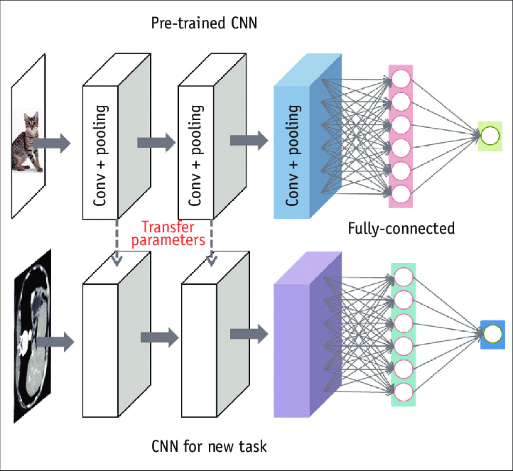

Pretrained backbone → new head

## Landmark Architectures

| Year | Model | Key Idea | Depth | Top-5 Error |
| --- | --- | --- | --- | --- |
| 1998 | LeNet-5 | End-to-end CNN for digits | 5 | — |
| 2012 | **AlexNet** | ReLU + Dropout + GPU training | 8 | 16.4% |
| 2014 | VGG-16 | Deep stacks of 3×3 convs | 16 | 7.3% |
| 2014 | GoogLeNet | Inception module (multi-scale) | 22 | 6.7% |
| 2015 | **ResNet** | **Skip connections** → very deep | 152 | 3.6% |
| 2017 | DenseNet | Dense connectivity | 201 | — |

**Trend:** deeper networks + better shortcuts → better performance.

## Skip Connections: Why They Matter

**Residual block:** $\quad y = \mathcal{F}(x) + x$

The gradient through a residual block:
$$\frac{\partial L}{\partial x} = \frac{\partial L}{\partial y}\left(\mathbf{I} + \frac{\partial \mathcal{F}}{\partial x}\right)$$

- Even if $\frac{\partial \mathcal{F}}{\partial x} \to 0$, the gradient still flows through the **identity path** ($\mathbf{I}$).
- Solves the **vanishing gradient** problem.
- Enables training networks with **100+ layers**.
- The block only needs to learn the **residual** $\mathcal{F}(x) = y - x$ — often easier than learning the full mapping.

```
    x ─────────────────┐
    │                   │
    ▼                   │
  [Conv → BN → ReLU]   │
    │                   │
    ▼                   │
  [Conv → BN]          │
    │                   │
    ▼                   │
    + ◀─────────────────┘
    │
    ▼
   ReLU
    │
    ▼
    y = F(x) + x
```

## CNNs for 1-D Signals

CNNs are **not just for images** — a natural fit for many SP tasks:

| Task | Input | Network |
| --- | --- | --- |
| Audio classification | Log-mel **spectrogram** (2-D) | 2-D CNN |
| Speech / keyword spotting | MFCC or raw waveform | 1-D / 2-D CNN |
| ECG / EEG arrhythmia | Multi-channel time series | 1-D CNN |
| Vibration fault detection | Accelerometer waveform | 1-D CNN |

```python
# 1-D conv for a single-channel signal: same API, just Conv1d instead of Conv2d
nn.Conv1d(in_channels=1, out_channels=16, kernel_size=7, padding=3)
# Input shape: [batch, channels, time_steps]
# Output shape: [batch, 16, time_steps]   (with padding=3, stride=1)
```

*Same math, same output-size formula — just one spatial axis instead of two.*

## Regularization Round-Up

| Technique | Purpose | Where / How |
| --- | --- | --- |
| **Weight Decay (L2)** | Penalize large weights | $L = L_0 + \lambda \lVert w \rVert_2^2$ (in optimizer) |
| **Dropout** | Random sub-networks | After FC / late conv layers |
| **Data Augmentation** | Enlarge effective dataset | Input pipeline (training only) |
| **Batch Normalization** | Stabilize activations | After every conv layer |
| **Label Smoothing** | Soften one-hot targets | $y_i' = (1-\alpha) y_i + \alpha/K$ (in loss) |
| **Early Stopping** | Prevent over-training | Monitor validation loss, stop when it rises |

**Note**

In practice, you use **all of these together**. They are complementary, not competing.

## Advantages vs. Limitations

| Strengths | Limitations |
| --- | --- |
| Parameter-efficient (weight sharing) | Data-hungry (need lots of images) |
| Translation equivariant | Heavy compute for large inputs |
| Transfer-learning friendly | Not rotation / scale invariant |
| Learns hierarchical features | Less interpretable than linear models |
| Works for 1-D, 2-D, 3-D data | Fixed receptive field (no long-range) |

> **Remedies:** group-equivariant CNNs (rotations), depthwise-separable convs (MobileNet), attention / **transformers** for long-range dependencies.

## Summary

- **CNN = stack of Conv → BN → ReLU → Pool**, topped by a FC head.
- **Why it works:** locality, weight sharing, translation equivariance.
- **Key formula:** $H_{\text{out}} = \lfloor(H_{\text{in}} - K + 2P)/S\rfloor + 1$
- **Training recipe:** AdamW + cosine LR + BN + dropout + augmentation.
- **Scale up:** transfer learning from pretrained backbones (don’t train from scratch).
- **SP relevance:** 1-D CNNs on raw signals; 2-D CNNs on spectrograms.

## Next Week

**Transformers** — sequence modeling with self-attention, the modern successor to CNNs for many SP tasks.